# Analyzing resting-state EEG and Spelling Performance in Young Adults

Leandro Ledesma

2024-03-13

### Universal block code settings

```r
knitr::opts_chunk$set(echo = FALSE)
knitr::opts_chunk$set(message = FALSE)
knitr::opts_chunk$set(comment = NULL)
knitr::opts_chunk$set(warning = FALSE)
```

### Index subjects by those that met the requirements

- No self-report injury
- No Epilepsy
- Removing missing data
- No one below ‘IQ’ of 70 (more than 2 SD below the mean)
- Extremely poor spellers (more than 3 SD below the mean)
- Issues with EEG recordings
- Did not survive EEG cleaning

### Missing data

- All data should be present based on the index from the previous section

This is an automated response: The current dataset has the dimensions 449 x 23 . Below is a frequency table showing the number of missing data for each variable.

[output not shown]

This is an automated response: Our final sample size is n= 449

## Descriptive statistics of the data

We can use the describe() function from the psych package to give us descriptive statistics from the variables that will be incorporated into the model. We will create 3 tables. The first will contain information about the continuous predictors. The next will have the frequency of the categorical variables. Lastly we will have a table for the resting-state EEG frequency bands.

### Continuous predictors

Table 1: Descriptive Statistics of Continuous Predictors

|  | Mean | Median | SD | Min | Max | Range | n |
| --- | --- | --- | --- | --- | --- | --- | --- |
| Spelling Error | 13.38 | 12 | 8.62 | 0 | 41 | 41 | 449 |
| Age | 20.27 | 19 | 4.44 | 15 | 36 | 21 | 449 |
| CFIT Raw Scores | 30.87 | 32 | 5.37 | 18 | 42 | 24 | 449 |

### Categorical predictors

Table 2: Descriptive Statistics of Categorical Variables.

| Female | Male | Male (%) | Bio F. | Insti. | Bio F. (%) | N |
| --- | --- | --- | --- | --- | --- | --- |
| 256 | 193 | 43 | 246 | 203 | 55 | 449 |

Table 2: Descriptive Statistics of Categorical Variables.

|  | Female | Male | Total |
| --- | --- | --- | --- |
| Bio F. | 153 | 93 | 246 |
| Insti. | 103 | 100 | 203 |
| Total | 256 | 193 | 449 |

### Descriptive statistics of the EEG data

- Right now this is for eyes-closed only

Descriptive Statistics of Power from each Frequency Band (Frontal)

| Frequency Band | Mean | Median | SD | Min | Max | Range | n |
| --- | --- | --- | --- | --- | --- | --- | --- |
| Delta (0.5-3.75Hz) | 2.48 | 1.97 | 1.67 | 0.49 | 13.18 | 12.69 | 449 |
| Theta (4-7.75Hz) | 0.49 | 0.38 | 0.36 | 0.11 | 3.32 | 3.20 | 449 |
| Alpha (8-12Hz) | 1.11 | 0.81 | 1.04 | 0.07 | 8.85 | 8.78 | 449 |
| Beta (12-30Hz) | 0.10 | 0.08 | 0.07 | 0.03 | 0.88 | 0.85 | 449 |

Descriptive Statistics of Power from each Frequency Band (Temporal)

| Frequency Band | Mean | Median | SD | Min | Max | Range | n |
| --- | --- | --- | --- | --- | --- | --- | --- |
| Delta (0.5-3.75Hz) | 1.46 | 1.26 | 0.77 | 0.34 | 6.08 | 5.75 | 449 |
| Theta (4-7.75Hz) | 0.51 | 0.37 | 0.43 | 0.10 | 3.57 | 3.47 | 449 |
| Alpha (8-12Hz) | 0.90 | 0.74 | 0.65 | 0.07 | 3.48 | 3.42 | 449 |
| Beta (12-30Hz) | 0.15 | 0.12 | 0.11 | 0.02 | 0.99 | 0.97 | 449 |

Descriptive Statistics of Power from each Frequency Band (Parietal)

| Frequency Band | Mean | Median | SD | Min | Max | Range | n |
| --- | --- | --- | --- | --- | --- | --- | --- |
| Delta (0.5-3.75Hz) | 1.14 | 0.97 | 0.69 | 0.32 | 5.94 | 5.62 | 449 |
| Theta (4-7.75Hz) | 0.48 | 0.32 | 0.49 | 0.07 | 3.96 | 3.89 | 449 |
| Alpha (8-12Hz) | 1.71 | 1.19 | 1.68 | 0.05 | 12.34 | 12.28 | 449 |
| Beta (12-30Hz) | 0.10 | 0.08 | 0.06 | 0.01 | 0.35 | 0.34 | 449 |

Descriptive Statistics of Power from each Frequency Band (Occipital)

| Frequency Band | Mean | Median | SD | Min | Max | Range | n |
| --- | --- | --- | --- | --- | --- | --- | --- |
| Delta (0.5-3.75Hz) | 2.12 | 1.71 | 1.45 | 0.39 | 14.37 | 13.97 | 449 |
| Theta (4-7.75Hz) | 0.86 | 0.60 | 0.82 | 0.12 | 6.89 | 6.77 | 449 |
| Alpha (8-12Hz) | 4.31 | 3.04 | 4.44 | 0.07 | 35.74 | 35.67 | 449 |
| Beta (12-30Hz) | 0.21 | 0.18 | 0.15 | 0.04 | 1.63 | 1.59 | 449 |

### Visualizing all continuous variables as histograms

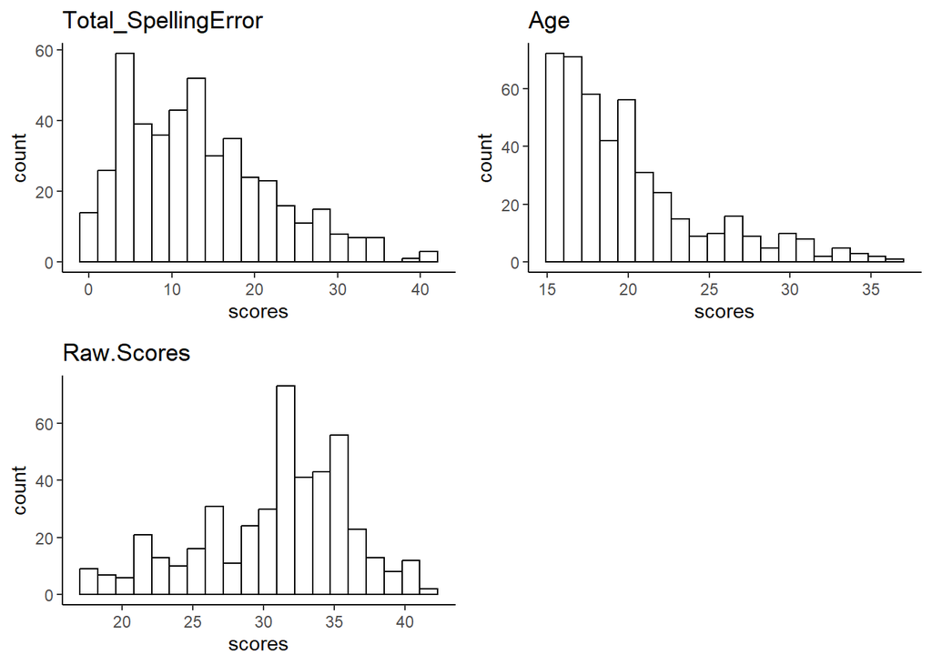

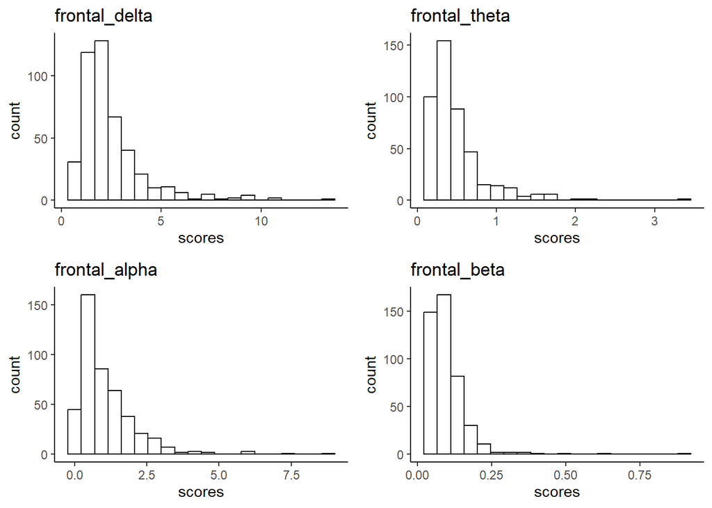

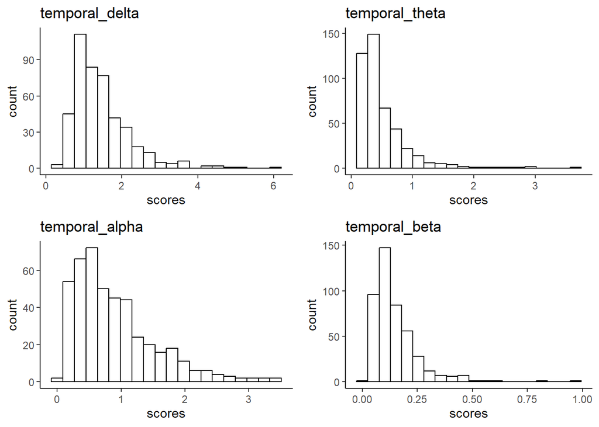

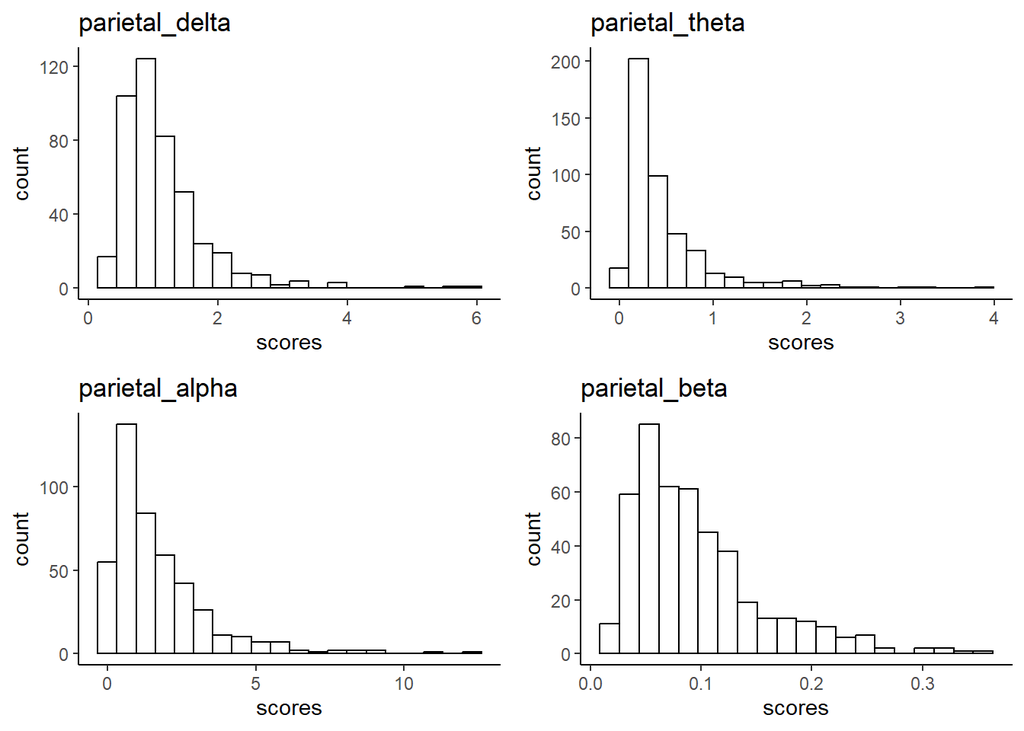

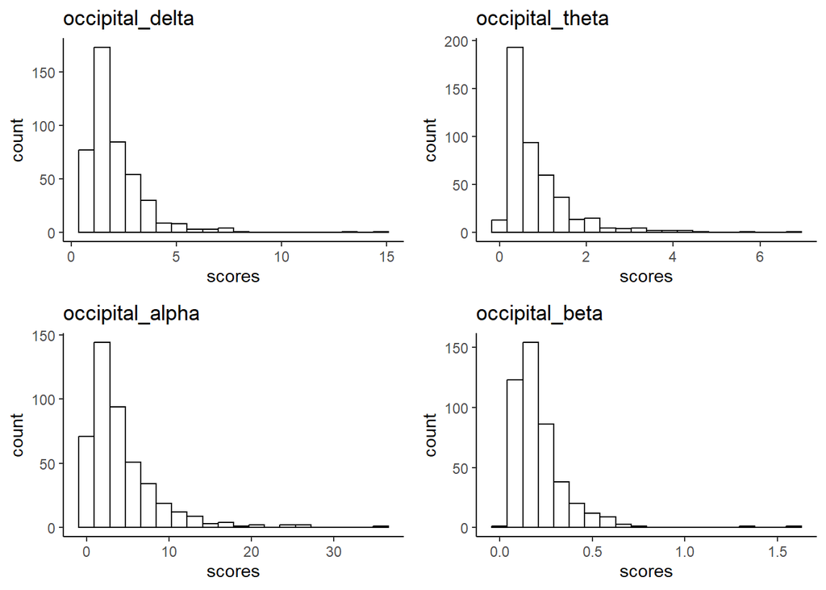

- The Frequency Bands (Outcome Measures) do not look parametric. Thus we will log transform the variables to see if that will help with the distribution of scores.
- Because there is a value of 0 for total spelling error, we replaced them to .1 to prevent getting infiniity as a value for the log transformation. This does not change the ranks of the 0’s in the vector since the next lowest score is 1.

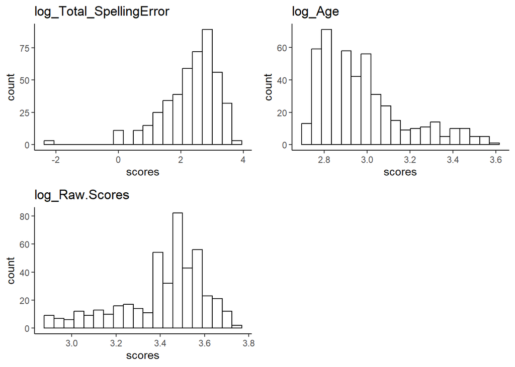

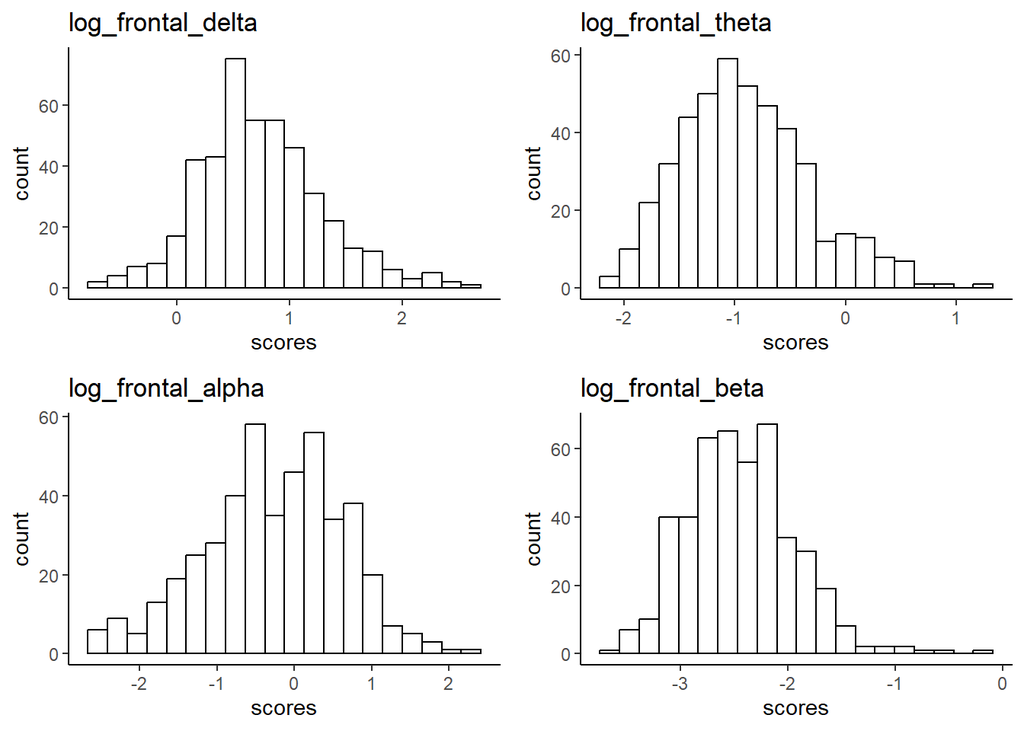

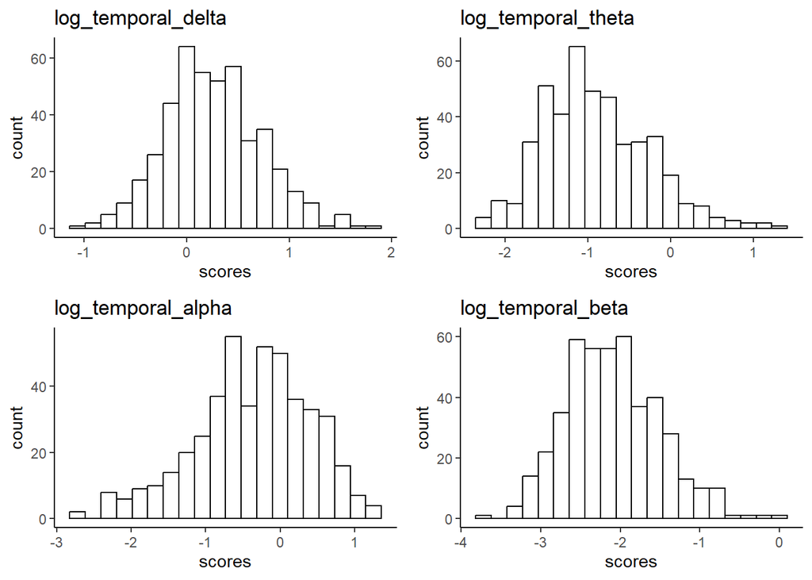

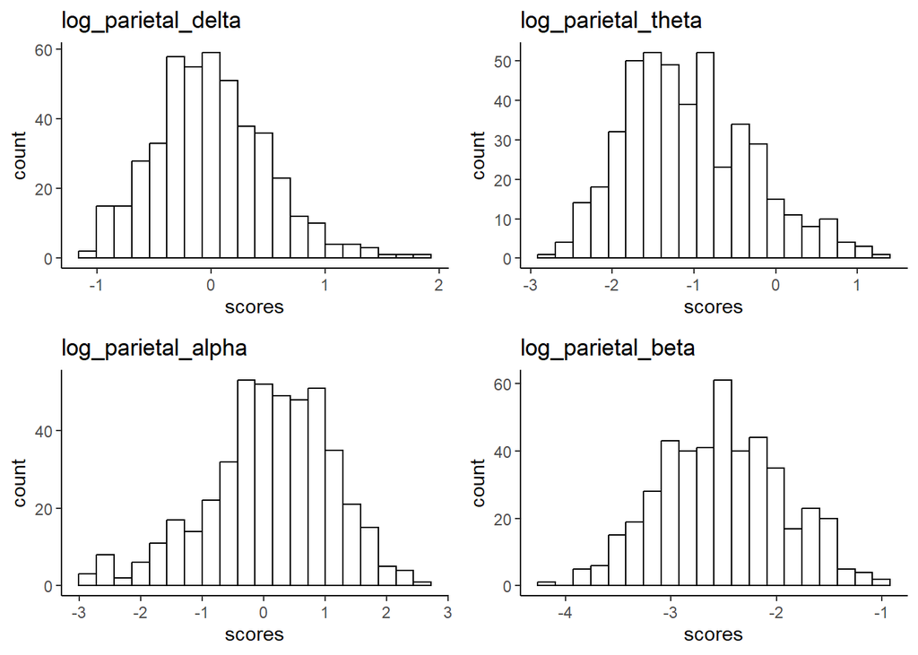

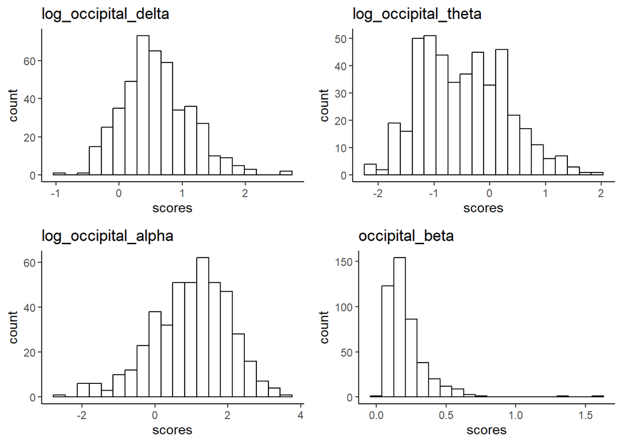

Descriptive Statistics of Log Power Predictors

|  | Mean | Median | SD | Min | Max | Range | n |
| --- | --- | --- | --- | --- | --- | --- | --- |
| Spelling Error | 2.32 | 2.48 | 0.87 | -2.30 | 3.71 | 6.02 | 449 |
| Age | 2.99 | 2.94 | 0.20 | 2.71 | 3.58 | 0.88 | 449 |
| CFIT Raw Scores | 3.41 | 3.47 | 0.19 | 2.89 | 3.74 | 0.85 | 449 |

Descriptive Statistics of Log Power from each Frequency Band (Frontal)

| Frequency Band | Mean | Median | SD | Min | Max | Range | n |
| --- | --- | --- | --- | --- | --- | --- | --- |
| Delta (0.5-3.75Hz) | 0.75 | 0.68 | 0.55 | -0.72 | 2.58 | 3.30 | 449 |
| Theta (4-7.75Hz) | -0.90 | -0.96 | 0.58 | -2.17 | 1.20 | 3.37 | 449 |
| Alpha (8-12Hz) | -0.27 | -0.22 | 0.90 | -2.64 | 2.18 | 4.82 | 449 |
| Beta (12-30Hz) | -2.44 | -2.47 | 0.50 | -3.60 | -0.13 | 3.48 | 449 |

Descriptive Statistics of Log Power from each Frequency Band (Temporal)

| Frequency Band | Mean | Median | SD | Min | Max | Range | n |
| --- | --- | --- | --- | --- | --- | --- | --- |
| Delta (0.5-3.75Hz) | 0.26 | 0.23 | 0.47 | -1.08 | 1.81 | 2.89 | 449 |
| Theta (4-7.75Hz) | -0.90 | -0.98 | 0.64 | -2.30 | 1.27 | 3.57 | 449 |
| Alpha (8-12Hz) | -0.37 | -0.30 | 0.78 | -2.73 | 1.25 | 3.98 | 449 |
| Beta (12-30Hz) | -2.09 | -2.14 | 0.58 | -3.72 | -0.01 | 3.72 | 449 |

Descriptive Statistics of Log Power from each Frequency Band (Parietal)

| Frequency Band | Mean | Median | SD | Min | Max | Range | n |
| --- | --- | --- | --- | --- | --- | --- | --- |
| Delta (0.5-3.75Hz) | 0.00 | -0.03 | 0.49 | -1.15 | 1.78 | 2.93 | 449 |
| Theta (4-7.75Hz) | -1.07 | -1.15 | 0.78 | -2.72 | 1.38 | 4.09 | 449 |
| Alpha (8-12Hz) | 0.10 | 0.17 | 1.01 | -2.92 | 2.51 | 5.44 | 449 |
| Beta (12-30Hz) | -2.51 | -2.51 | 0.58 | -4.22 | -1.05 | 3.18 | 449 |

Descriptive Statistics of Log Power from each Frequency Band (Occipital)

| Frequency Band | Mean | Median | SD | Min | Max | Range | n |
| --- | --- | --- | --- | --- | --- | --- | --- |
| Delta (0.5-3.75Hz) | 0.60 | 0.54 | 0.54 | -0.93 | 2.66 | 3.59 | 449 |
| Theta (4-7.75Hz) | -0.47 | -0.51 | 0.77 | -2.14 | 1.93 | 4.07 | 449 |
| Alpha (8-12Hz) | 0.98 | 1.11 | 1.06 | -2.64 | 3.58 | 6.22 | 449 |
| Beta (12-30Hz) | -1.72 | -1.72 | 0.58 | -3.18 | 0.49 | 3.67 | 449 |

### Run a correlation matrix for each frequency band

Correlation matrix of our continuous predictors and

|  | log_Total_SpellingError | log_Age | log_Raw.Scores | log_frontal_delta | log_frontal_theta | log_frontal_alpha | log_frontal_beta |
| --- | --- | --- | --- | --- | --- | --- | --- |
| log_Total_SpellingError | 1.000 | -0.241*** | -0.521*** | 0.114* | 0.129** | -0.012 | -0.002 |
| log_Age | -0.241*** | 1.000 | 0.116* | -0.257*** | -0.267*** | -0.087 | -0.082 |
| log_Raw.Scores | -0.521*** | 0.116* | 1.000 | -0.188*** | -0.076 | 0.036 | -0.047 |
| log_frontal_delta | 0.114* | -0.257*** | -0.188*** | 1.000 | 0.575*** | 0.238*** | 0.305*** |
| log_frontal_theta | 0.129** | -0.267*** | -0.076 | 0.575*** | 1.000 | 0.580*** | 0.489*** |
| log_frontal_alpha | -0.012 | -0.087 | 0.036 | 0.238*** | 0.580*** | 1.000 | 0.514*** |
| log_frontal_beta | -0.002 | -0.082 | -0.047 | 0.305*** | 0.489*** | 0.514*** | 1.000 |

Note:  
*** indicates p <.001  
** indicates p <.01  
* indicates p <.05

Correlation matrix of our continuous predictors and

|  | log_Total_SpellingError | log_Age | log_Raw.Scores | log_temporal_delta | log_temporal_theta | log_temporal_alpha | log_temporal_beta |
| --- | --- | --- | --- | --- | --- | --- | --- |
| log_Total_SpellingError | 1.000 | -0.241*** | -0.521*** | 0.117* | 0.069 | -0.021 | -0.062 |
| log_Age | -0.241*** | 1.000 | 0.116* | -0.358*** | -0.265*** | -0.087 | -0.017 |
| log_Raw.Scores | -0.521*** | 0.116* | 1.000 | -0.102* | 0.008 | 0.070 | -0.007 |
| log_temporal_delta | 0.117* | -0.358*** | -0.102* | 1.000 | 0.663*** | 0.368*** | 0.290*** |
| log_temporal_theta | 0.069 | -0.265*** | 0.008 | 0.663*** | 1.000 | 0.660*** | 0.395*** |
| log_temporal_alpha | -0.021 | -0.087 | 0.070 | 0.368*** | 0.660*** | 1.000 | 0.493*** |
| log_temporal_beta | -0.062 | -0.017 | -0.007 | 0.290*** | 0.395*** | 0.493*** | 1.000 |

Note:  
*** indicates p <.001  
** indicates p <.01  
* indicates p <.05

Correlation matrix of our continuous predictors and

|  | log_Total_SpellingError | log_Age | log_Raw.Scores | log_parietal_delta | log_parietal_theta | log_parietal_alpha | log_parietal_beta |
| --- | --- | --- | --- | --- | --- | --- | --- |
| log_Total_SpellingError | 1.000 | -0.241*** | -0.521*** | 0.176*** | 0.080 | -0.019 | -0.009 |
| log_Age | -0.241*** | 1.000 | 0.116* | -0.476*** | -0.292*** | -0.124** | -0.119* |
| log_Raw.Scores | -0.521*** | 0.116* | 1.000 | -0.138** | -0.025 | 0.064 | 0.058 |
| log_parietal_delta | 0.176*** | -0.476*** | -0.138** | 1.000 | 0.795*** | 0.523*** | 0.560*** |
| log_parietal_theta | 0.080 | -0.292*** | -0.025 | 0.795*** | 1.000 | 0.667*** | 0.605*** |
| log_parietal_alpha | -0.019 | -0.124** | 0.064 | 0.523*** | 0.667*** | 1.000 | 0.727*** |
| log_parietal_beta | -0.009 | -0.119* | 0.058 | 0.560*** | 0.605*** | 0.727*** | 1.000 |

Note:  
*** indicates p <.001  
** indicates p <.01  
* indicates p <.05

Correlation matrix of our continuous predictors and

|  | log_Total_SpellingError | log_Age | log_Raw.Scores | log_occipital_delta | log_occipital_theta | log_occipital_alpha | log_occipital_beta |
| --- | --- | --- | --- | --- | --- | --- | --- |
| log_Total_SpellingError | 1.000 | -0.241*** | -0.521*** | 0.180*** | 0.086 | -0.028 | 0.051 |
| log_Age | -0.241*** | 1.000 | 0.116* | -0.415*** | -0.235*** | -0.114* | -0.196*** |
| log_Raw.Scores | -0.521*** | 0.116* | 1.000 | -0.180*** | -0.054 | 0.025 | -0.038 |
| log_occipital_delta | 0.180*** | -0.415*** | -0.180*** | 1.000 | 0.759*** | 0.481*** | 0.495*** |
| log_occipital_theta | 0.086 | -0.235*** | -0.054 | 0.759*** | 1.000 | 0.654*** | 0.554*** |
| log_occipital_alpha | -0.028 | -0.114* | 0.025 | 0.481*** | 0.654*** | 1.000 | 0.632*** |
| log_occipital_beta | 0.051 | -0.196*** | -0.038 | 0.495*** | 0.554*** | 0.632*** | 1.000 |

Note:  
*** indicates p <.001  
** indicates p <.01  
* indicates p <.05

### Visualizing scatterplots

for predictors and frequency bands only

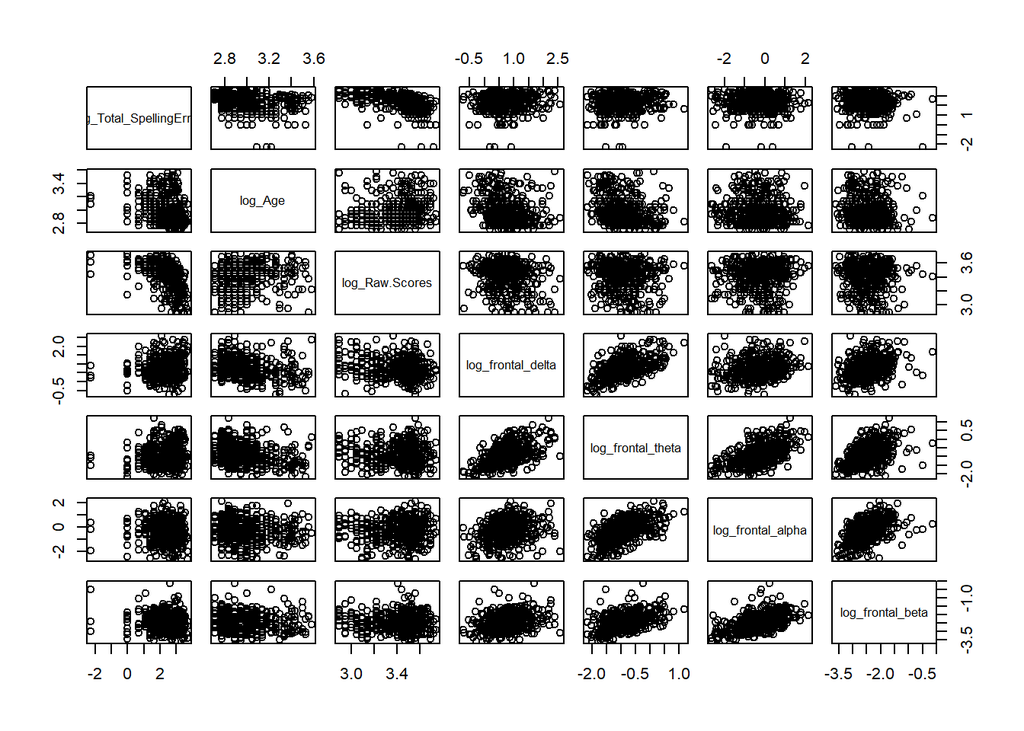

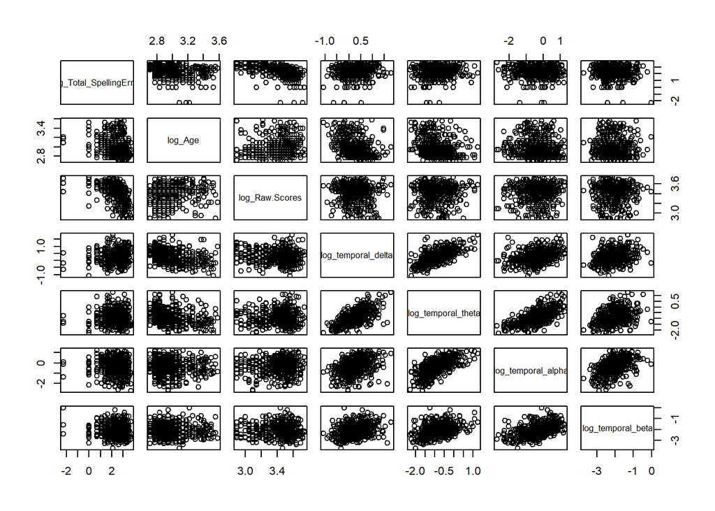

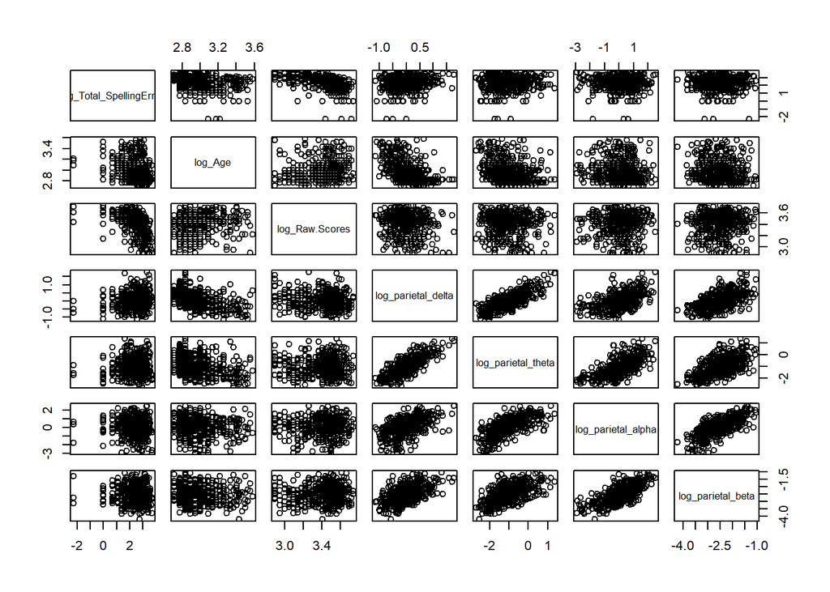

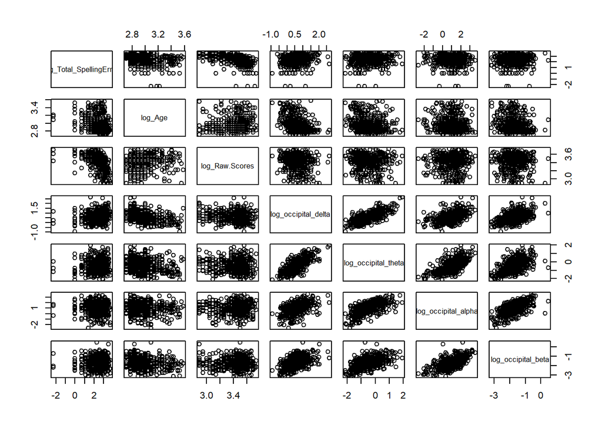

### Check for independence between categorical variables

P-value is significant. It seems there are more females who were raised in biological families than males. This may not be as big of a deal as initially thought.

```
     Group
Sex    BF  IC Sum
  F   153 103 256
  M    93 100 193
  Sum 246 203 449
```

```
   Group
Sex    BF    IC
  F 0.341 0.229
  M 0.207 0.223
```

```
    Pearson's Chi-squared test with Yates' continuity correction

data:  contingency.table
X-squared = 5.4978, df = 1, p-value = 0.01904
```